# Part 1: Elements of igraph

This document will focus on understanding an **igraph** graph and it’s two main components - **nodes** and **edges**. We can also use these components to filter the graph down to a **subgraph**.

First, we need to load the **igraph** package

```r
library(igraph)
```

# Building a graph

We now need to create a graph to explore. There are many different ways we can create a new graph, but here we will only cover three of those ways:

1. Adding vertices and edges to an empty graph by using
   - `make_empty_graph()`
   - `vertices()`
   - `edges()`
2. Converting an existing matrix into a graph by
   - creating a sparse square matrix with the rows and columns representing the nodes
   - Filling in elements with values to represent the edges
   - using `graph_from_adjacency_matrix()`
3. Converting existing data frames into a graph by
   - creating a data frame that represents an **edge list**
   - (optional) creating a data frame that represents a **node list**
   - using `graph_from_data_frame()`

### Building up an empty graph

When we build a graph up from an empty graph we need to first initiate the vertices so we can refer to them when we build the edges. It is important to note:

- Vertex names don’t have to be unique, but it is considered good practice
- Edges are defined in pairwise order
  - If `directed = F` then the order within the pair doesn’t matter
  - If `directed = T` then the first vertex in the pair is the source and the second is the target
- Attributes can be explicitly added to both vertices and edges

```r
g <- make_empty_graph(directed = T) +
  vertices(c('a', 'b', 'c', 'd', 'e'),
           type = "letter",
           order = c(1, 2, 3, 4, 5)) +
  edges(c('a', 'b',
          'b', 'c',
          'b', 'd',
          'c', 'b',
          'c', 'e'),
        type = "is connected to",
        weight = c(1, 1, 2, 1, 2))
```

Let’s take a look at how igraph represents a graph in R

```r
g
```

```
IGRAPH 1a780b9 DNWB 5 5 --
+ attr: name (v/c), type (v/c), order (v/n), type (e/c), weight (e/n)
+ edges from 1a780b9 (vertex names):
[1] a->b b->c b->d c->b c->e
```

igraph also provides a `plot()` to explore the graph visually

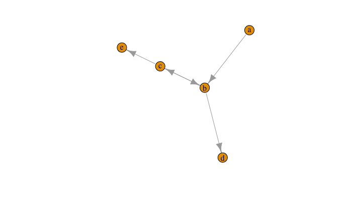

```r
set.seed(1234)
plot(g)
```

### Creating a graph from a matrix

The rows and columns of a matrix represent the vertices of a graph. If the element is not 0, then it represents a link between two vertices. It is important to note:

- The non-zero number matters regardless if the graph is weighted or not.
  - if `weighted = F` then it represents the number of links between the two vertices
  - if `weighted = T` then it represents the `weight` of the edge
  - if `weighted =` a character constant, the the number becomes an edge attribute named after the constant
- A symetric matrix is very different if the output graph is directed or not.
  - if `mode = "directed"` then the rows represent the **source** nodes and the columns represent the **target** nodes
  - if `mode = "undirected"` then only one element is chosen from either matrix[i][j] or matrix[j][i]

```r
src <- c('a', 'b', 'b', 'c', 'c')
tgt <- c('b', 'c', 'd', 'b', 'e')
wgt <- c(1, 1, 2, 1, 2)
matData <- matrix(0, nrow = 5, ncol = 5, dimnames = list(letters[1:5], letters[1:5]))
sapply(seq_along(src), function(i){
  matData[src[i], tgt[i]] <<- wgt[i]
})
```

```
[1] 1 1 2 1 2
```

```r
matData
```

```
  a b c d e
a 0 1 0 0 0
b 0 0 1 2 0
c 0 1 0 0 2
d 0 0 0 0 0
e 0 0 0 0 0
```

```r
g <- graph_from_adjacency_matrix(matData, mode = 'directed', weighted = 'weight')
g
```

```
IGRAPH b1178ca DNW- 5 5 --
+ attr: name (v/c), weight (e/n)
+ edges from b1178ca (vertex names):
[1] a->b b->c b->d c->b c->e
```

If we wanted to convert a graph back to a matrix, then we can do that as well:

- If no `attr` is provided, then an adjacency matrix is provided
- If `attr` is provided, the matrix is filled with that particular edge attribute. The attribute must be either numeric or logical

```r
as_adjacency_matrix(g)
```

```
5 x 5 sparse Matrix of class "dgCMatrix"
  a b c d e
a . 1 . . .
b . . 1 1 .
c . 1 . . 1
d . . . . .
e . . . . .
```

```r
as_adjacency_matrix(g, attr = 'weight')
```

```
5 x 5 sparse Matrix of class "dgCMatrix"
  a b c d e
a . 1 . . .
b . . 1 2 .
c . 1 . . 2
d . . . . .
e . . . . .
```

### Creating a graph from a data frame

The only data frame that is required to create a graph with `graph_from_data_frame()` is one representing an edges list. However, if we want the nodes to contain information other than their name, then we will need to also provide a data frame representing a node list. It is important to note:

- The first two columns of the edge list must represent the nodes the edges connect
  - If `directed = T` then the first column is the source and the second is the target
- If a node list is provided, then its first column must represent the name of the nodes
  - The names of the nodes must all be unique
  - Any nodes referred to in the edge list must exist in the node list

```r
node_list <- data.frame(
  name = c('a', 'b', 'c', 'd', 'e'),
  type = "letter",
  order = c(1, 2, 3, 4, 5)
)
edge_list <- data.frame(
  source = c('a', 'b', 'b', 'c', 'c'),
  target = c('b', 'c', 'd', 'b', 'e'),
  type = 'is connected to',
  weight = c(1, 1, 2, 1, 2)
)
g <- graph_from_data_frame(d = edge_list,
                           directed = T,
                           vertices = node_list)
```

The resulting graph is, for all intents and purposes, identical to the one we built from an empty graph.

```r
g
```

```
IGRAPH 97e247b DNWB 5 5 --
+ attr: name (v/c), type (v/c), order (v/n), type (e/c), weight (e/n)
+ edges from 97e247b (vertex names):
[1] a->b b->c b->d c->b c->e
```

We can also convert the graph back to a data frame:

- The `what` argument accepts the strings “edges”, “vertices”, or “both” and will return the appropriate data frame. If ‘both’ is entered, then a list with bothe data frames is returned.

```r
as_data_frame(g, 'both')
```

|  | name | type | order |
| --- | --- | --- | --- |
| a | a | letter | 1 |
| b | b | letter | 2 |
| c | c | letter | 3 |
| d | d | letter | 4 |
| e | e | letter | 5 |

|  | from | to | type | weight |
| --- | --- | --- | --- | --- |
| 1 | a | b | is connected to | 1 |
| 2 | b | c | is connected to | 1 |
| 3 | b | d | is connected to | 2 |
| 4 | c | b | is connected to | 1 |
| 5 | c | e | is connected to | 2 |

```
NA
```

# Accessing & Manipulating graph components

Graphs are built with nodes and edges. These components have data stored in them and it is important to understand how this data can be accessed. The two work hourses of graph exploration in igraph are:

- `V()` to access and manipulate data stored in vertices
- `E()` to access and manipulate data stored in edges

Once we are comfortable with those two functions, we can use them to make a subgraph with either:

- `induced_subgraph()` if we have vector of vertices
- `subgraph.edges()` if we have a vector of edges

### V()

`V()` only accepts an igraph graph object and returns a vector of vertices. This vector is what we use to explore the vertices of the graph and it acts like a normal `c()` vector in R with some syntactic sugar

```r
V(g)
```

```
+ 5/5 vertices, named, from 97e247b:
[1] a b c d e
```

You can access information of a specific vertex by inputting its index number.

```r
V(g)[3]
```

```
+ 1/5 vertex, named, from 97e247b:
[1] c
```

If the vertex has a name, then you can use its name instead of the index number.

```r
V(g)['c']
```

```
+ 1/5 vertex, named, from 97e247b:
[1] c
```

Accessing a vertex using double square bracket notation gives you all the information stored in it.

```r
V(g)[['c']]
```

```
+ 1/5 vertex, named, from 97e247b:
  name   type order
3    c letter     3
```

A specific attribute can be accessed using dollar sign notation. You should use single square bracket notation when accesing specific attributes.

```r
V(g)$order
```

```
[1] 1 2 3 4 5
```

```r
V(g)['c']$order
```

```
[1] 3
```

You can use the assignment arrow (`<-`) to change information of a particular vertex

```r
V(g)['c']$order <- 1
#vcount provides the number of vertices in a graph
V(g)[[1:vcount(g)]]
```

```
+ 5/5 vertices, named, from 97e247b:
  name   type order
1    a letter     1
2    b letter     2
3    c letter     1
4    d letter     4
5    e letter     5
```

You can access multiple vertices either by providing a vector of names

```r
V(g)[[c('c', 'e')]]
```

```
+ 2/5 vertices, named, from 97e247b:
  name   type order
3    c letter     1
5    e letter     5
```

You can also **query the attributes** of the vertex vector.

```r
V(g)[[order == 1]]
```

```
+ 2/5 vertices, named, from 97e247b:
  name   type order
1    a letter     1
3    c letter     1
```

Vertex vectors can be combined just like any other vector in R

```r
ab <- V(g)[[c('a', 'b')]]
de <- V(g)[[c('d', 'e')]]
c(ab, de)
```

```
+ 4/5 vertices, named, from 97e247b:
[1] a b d e
```

### E()

`E()` behves much in the same way as `V()`. It only accepts an igraph graph object and returns a vector of edges. A big difference, however, is how we approach accessing data stroed in edges. While edges can have names and can be accessed directly using either a name or an id, this is not the best approach since as graphs get larger, the sheer number and variety of edges make it very impractical to do so.

```r
E(g)
```

```
+ 5/5 edges from 97e247b (vertex names):
[1] a->b b->c b->d c->b c->e
```

Instead edges should be accessed by querying their attributes

```r
E(g)[weight == 2]
```

[output not shown]

```r
E(g)[weight == 2]
```

```
+ 2/5 edges from 97e247b (vertex names):
[1] b->d c->e
```

```r
E(g)[[weight == 2]]
```

```
+ 2/5 edges from 97e247b (vertex names):
  tail head tid hid            type weight
3    b    d   2   4 is connected to      2
5    c    e   3   5 is connected to      2
```

```r
E(g)[weight == 2]$weight <- -20000
#ecount() provides the number of edges in a graph
E(g)[[1:ecount(g)]]
```

```
+ 5/5 edges from 97e247b (vertex names):
  tail head tid hid            type weight
1    a    b   1   2 is connected to      1
2    b    c   2   3 is connected to      1
3    b    d   2   4 is connected to -20000
4    c    b   3   2 is connected to      1
5    c    e   3   5 is connected to -20000
```

```r
E(g)['a' %--% 'b']
```

```
+ 1/5 edge from 97e247b (vertex names):
[1] a->b
```

```r
E(g)['c' %<-% 'b']
```

```
+ 1/5 edge from 97e247b (vertex names):
[1] b->c
```

```r
#you don't need to now the specific name of the vertices
E(g)['b' %->% V(g)]
```

```
+ 2/5 edges from 97e247b (vertex names):
[1] b->c b->d
```

# Subgraphs

`induced_subgraph()` filters the graph to include only the vertices within the provided vertex vector or vector of vertex names. Any edges between the provided nodes are preserved.

```r
abc_sub <- induced_subgraph(g, c('a', 'b', 'c'))
abc_sub
```

```
IGRAPH d8f4b60 DNWB 3 3 --
+ attr: name (v/c), type (v/c), order (v/n), type (e/c), weight (e/n)
+ edges from d8f4b60 (vertex names):
[1] a->b b->c c->b
```

```r
b <- E(g)['b' %->% V(g)]
c <- E(g)['c' %->% V(g)]
c(b, c)
```

```
+ 4/5 edges from 97e247b (vertex names):
[1] b->c b->d c->b c->e
```

### Subgraphs Gotchas

In igraph, subgraphs are completely new graphs and their components are completely different from those of the graphs they were created from. The below won’t work:

```r
E(g)[V(b_sub)['b'] %--% V(abc_sub)]
```

[output not shown]

Instead, you will need to use attributes that you know are in both graphs, like names:

```r
E(g)[V(b_sub)['b']$name %--% V(abc_sub)$name]
```

[output not shown]

```
+ 3/5 edges from 97e247b (vertex names):
[1] a->b b->c c->b
```

Also, ids don’t stay consistent when a subgraph is created. That is, `V(g)[3]` won’t necessarily represent the same vertex in the subgraph `V(subg)[3]`. It is good practice to name the vertices and use the vertex names to keep things consistent. `V(g)["person_1"]` will be the same in the subgraph `V(subg)["person_1"]`